# Deep IV: A Flexible Approach for Counterfactual Prediction

$$\textbf{Deep IV: A Flexible Approach for Counterfactual Prediction}$$

$$\text{Implementing Jason Hartford, Greg Lewis, Kevin Leyton-Brown, and Matt Taddy (2017)}$$

$$\text{Tutorial by Andrew Doherty Munro}$$

$$\text{PLSC 40601 - Advanced Topics in Causal Inference, Spring 2026}$$

1. Introduction
2. Problem Set Up and Background
   1. Instrumental Variables
   2. Neural Networks
3. The Deep IV Framework
4. Implementation
   1. Data Generation
   2. The First Stage
   3. The Second Stage
   4. Putting it All Together
   5. Evaluation
5. Sources

# Introduction

This tutorial implements Hartford et. al 2017, "Deep IV: A Flexible Approach for Counterfactual Prediction." This paper extends the instrumental variable framework to a nonparametric, flexible setting by combining it with deep learning. This tutorial seeks to serve two purposes: 1. provide a general framework for how one would implement a strategy such as this, and 2. test the model in a setting it is not designed to handle: where there is a binary treatment and instrument. Thus, it will allow us to investigate how "durable" the model is to data-generating processes outside of flexible, nonlinear ones. Thus, if you get the data-generating process badly wrong, is DeepIV still salvageable?

# Problem Set Up and Background

### General Framework

In the following sections, the following notation will be used:

- $D \in \{0, 1\}$: treatment, which takes on the values (1) when an individual is treated and (0) otherwise.
- $X$: observed covariates.
- $Y$: observed outcome of interest
- $Y(1), Y(0)$: $\textit{potential}$ outcomes, or the outcome that would occur under treatment or control.
- $Z \in \{0, 1\}$: our instrument.

A general assumption in causal inference is ignorability of treatment, or the following:

$$Y(1), Y(0) \perp\!\!\!\perp T | X$$

This allows us to recover the average treatment effect:

$$E[Y(1) - Y(0)] = E[Y(1)] - E[Y(0)] = E[Y | T = 1] - E[Y | T = 0]$$

The key problem that instrumental variables seek to solve is when ignorability fails - our treatment is $\textbf{not}$ independent of potential outcomes, even conditional on covariates, which means estimation of the ATE will be biased.

## Instrumental Variables

Instrumental variables leverage an exogenous instrument, $Z$, that is correlated with our endogenous treatment $D$ and affects our outcome $Y$ $\textit{only through its relationship with}$ $D$. The specific assumptions for DeepIV will be outlined in Section 3.

Thus, with the presence of an instrument, we can recover the Local Average Treatment Effect (LATE), or the ATE for the individuals induced into treatment by the instrument:

$$LATE = E[Y_i(1) - Y_i(0) | D_i(1) - D_i(0) = 1]$$

Which is estimated using the Wald estimator:

$$\text{LATE} = \frac{E[Y_i \mid Z_i = 1] - E[Y_i \mid Z_i = 0]}{E[D_i \mid Z_i = 1] - E[D_i \mid Z_i = 0]}$$

This will be the estimand to which we compare the DeepIV estimator.

(Angrist, Imbens, and Rubin 1996)

# Neural Networks

A neural network is a highly flexible, nonlinear machine-learning model designed to mimic the neurons in the brain - hence, "neural net". The below will outline a "single layer" neural network, or a network with an input layer, a hidden layer, and an output layer.

To begin, the general form of a neural network is as follows:

$$f(X) = \beta_0 + \sum_{k=1}^K \beta_k h_k(X)$$

*The submitted notebook references a neural-network diagram that was not included in the project files.*

James et al. 2023 (p. 400)

Thus, each $A$ in the hidden layer is a weighted sum of each value of the input layer, and the final output $f(X)$ is a transformed, weighted sum of this hidden layer. Thus, every unit in the hidden layer can be written as:

$$A_k = h_k(X) = g(w_{k0} + \sum_{j=1}^p w_{kj}X_j)$$

where $p$ indexes the number of observations and g(z) is some nonlinear function. Thus, each activation unit in the hidden layer is a weighted sum (plus a constant term) of each of the input units. Then, the final output $f(X)$ is the transformation $g()$ of a weighted sum of these input layers, plus a constant, the general form of which can be written as:

$$f(X) = \beta_0 + \sum_{k=1}^K \beta_k A_k = \beta_0 \sum_{k=1}^K \beta_k g(w_{k0} + \sum_{j=1}^p w_{kj}X_j)$$

It's vital the $g(z)$ is a nonlinear function, otherwise this would just be Ordinary Least Squares. Generally $g()$ takes the form of either a sigmoid function:

$$g(z) = \frac{1}{1 + e^{-z}}$$

or a Rectified Linear Unit activation function (ReLU):

$$g(z) = \begin{cases} z & \text{if } z > 0 \\ 0 & \text{otherwise} \end{cases}$$

"Deep Learning" just refers to a neural network with multiple hidden layers. The upshot from all of this is that a neural network is a highly flexible, nonlinear way of approximating a given function $f(X)$.

(James et al. 2023)

# The DeepIV Framework

Traditionally, IVs assume linear and homogenous treatment effects; e.g., all units have the same treatment effect, which is linear in parameters. While other methods have been used to expand IV using nonparametric, nonlinear models, the authors state that DeepIV has the advantage that 1. the researcher does not need a strong understanding of the data-generating process, and 2. the complexity of the model does not "explode" as your input space grows.

Consider the following model:

$$Y = g(D, X) + \epsilon$$

Where, as above $g()$ is some (possibly nonlinear) function, and $\epsilon_i$ are random errors. Thus, Y is structurally determined by treatment $D$, covariates $X$, and random unobservable noise. To recover our ATE estimand, we need to estimate the counterfactual prediction function, defined as:

$$h(D, X) = g(D, X) + E[\epsilon | X]$$

The core issue is that $h(D_1, X) - h(D_0, X) \neq g(D_1, X) - g(D_0, X)$ because $E[\epsilon | X, D] \neq 0$. This is the source of our treatment endogeneity - $D$ is related to some unobserved confounder. Thus, the typical objective in this setting - fitting a model to estimate $E[Y | D, X]$ - will result in a biased estimand because $D$ is not strongly ignorable.

Thus, with an instrument $Z$, our DeepIV has the following assumptions:

1. $\textit{Relevance}$: the distribution of D given X and Z, $F(D | X, Z)$, is not constant in Z. In other words, treatment and our instrument are correlated.
2. $\textit{Exclusion}$: $Z \perp\!\!\!\perp Y | (X, T, \epsilon)$
3. $\textit{Unconfoundedness}$: Z is conditionally independent of the error, $Z \perp\!\!\!\perp \epsilon | X$

We are now ready to define the equation we wish to estimate. Take our original model:

$$Y = g(D, X) + \epsilon$$

and take the expectation of both sides, conditional on $X, Z$:

$$E[y | X, Z] = E[g(D, X) | X, Z] + E[\epsilon | X] = \int h(D, X)dF(D | X, Z)$$

where, to reiterate, $h()$ is our counterfactual predication function defined above, and $F(D | X, Z)$ is the conditional treatment distribution.

Thus, Deep IV has two stages, analogous in spirit to 2-Stage Least Squares/the Wald Estimator:

1. A density estimation procedure of $\hat{F}(D | X, Z)$ (Treatment Network)
2. An estimation of counterfactual prediction function $h()$ using the treatment distribution estimated in Stage 1 (Outcome Network)

# Implementation

Hartford et al. show the model's performance in comparison to a FeedForward Neural Net, a typical linear 2-Stage Least Squares, and a non-parametric IV polynomial kernel regression in a nonlinear setting, showing it outperforms them all. This tutorial will instead focus on a linear, binary setting to test whether DeepIV can perform just as well as standard Wald Estimator, which is specifically designed for this setting. Thus, it will demonstrate both the process of implementing the strategy, as well as test whether there is a "downside" to implementing it in a setting where you may not know if your underlying relationships are linear or nonlinear.

Begin by specifying a data-generating process. Let our covariates X be standard normal, and instrument Z be binomial with $p=0.5$. Then, specify the following linear relationships:

$$D = \begin{cases} 1 & \text{if } \pi Z + X + \nu > 0 \\ 0 & \text{otherwise} \end{cases}$$

$$Y = \beta D + X + \epsilon$$

The key here is to induce endogeneity by making $\nu$ and $\epsilon$ related; they are drawn from a multivariate normal, which means that D will be correlated with $\epsilon$. We'll also make D cleanly categorical (aka, 0 or 1), where it's equal to 0 if it's "latent" value (dependent on Z, X, and $\nu$) is negative and 1 if it's positive. We'll specify a $\beta$ of 3 for our ATE and a $\pi$ of 0.5 for the relationship between our instrument $Z$ and treatment $D$. We'll make the errors correlated pretty strongly, with a default value of 0.7, making our treatment quite endogeous. Can such a flexible network recover the ATE in this setting?

### Data Generation

```python
import numpy as np
import pandas as pd
import torch
import torch.nn as nn
import matplotlib.pyplot as plt
from sklearn.linear_model import LinearRegression
from scipy.stats import gaussian_kde
from sklearn.model_selection import train_test_split
import seaborn as sns
import copy

np.random.seed(40601)
torch.manual_seed(40601)

def generate_data(n=10000, beta=3.0, pi=0.5, rho=0.7, seed=None):
    rng = np.random.default_rng(seed)

    #let Z and X both be standard normal
    Z = rng.binomial(1, 0.5, n)
    X = rng.normal(0, 1, n)

    #draw errors from a bivariate normal distribution to correlate treatment with errors
    errors = rng.multivariate_normal([0, 0], [[1, rho], [rho, 1]], n)

    epsilon = errors[:, 0]
    nu = errors[:, 1]

    #ensure relevance of instrument. use categorical treatment for now
    D_latent = pi * Z + X + nu

    #0 if latent value is negative, otherwise 1.
    D = (D_latent > 0).astype(int)

    #final model
    Y = beta * D + X + epsilon

    return pd.DataFrame({'Z': Z, 'X': X, 'D': D, 'Y': Y})
```

```python
data = generate_data(seed=40601)
data.head()
```

|  | Z | X | D | Y |
| --- | --- | --- | --- | --- |
| 0 | 0 | -0.424915 | 0 | -1.821800 |
| 1 | 1 | 1.041489 | 1 | 4.147058 |
| 2 | 1 | -0.068854 | 1 | 4.728412 |
| 3 | 0 | -1.672040 | 0 | -0.521681 |
| 4 | 0 | 0.516343 | 0 | -0.084872 |

The first stage in Deep IV is estimating the treatment distribution using a Deep Neural Network. Because our treatment is categorical, this is essentially just a classification problem. For continuous treatment the NN estimates a Mixture Density Network, which outputs the parameters of a mixture of Gaussian distributions. For demonstration purposes, the classification problem is more straightforward. Note that instead of a single output, $f(x)$, the neural net will output classification probabilities (e.g $Pr[D=1]$ and $Pr[D=0]$), but because we only have two treatments, we'll just use the probability of receiving treatment.

The below is an implementation of a basic PyTorch classification neural net. This was made with assistance from the following resources:

- the PyTorch documentation: https://docs.pytorch.org/tutorials/beginner/basics/buildmodel_tutorial.html#
- James Hartford's GitHub for DeepIV: https://github.com/jhartford/DeepIV (note, his packages are out of date, which is why I don't use them. I mainly use his code to check on the structure of mine and choose some of the same model parameters he does)

### The First Stage

Begin by defining the first stage Neural Net using the PyTorch library:

```python
class TreatmentNN(nn.Module):
    def __init__(self, input_size, hidden_layers):
        super().__init__()
        layers = []
        in_dim = input_size #number of nodes on input layer
        for h in hidden_layers:
            layers += [nn.Linear(in_dim, h), nn.ReLU()] #build the layers of the network
            in_dim = h
        layers.append(nn.Linear(in_dim, 2)) #input dimension: our input size. output dimension: 2 values (one per treatment type)
        self.net = nn.Sequential(*layers)

    def forward(self, z, x):
        """Feed in Z and X, returns treatment logits"""
        inp = torch.cat([z, x], dim=-1)
        return self.net(inp)

    def sample(self, z, x, n_samples=5):
        """
        1. get logits from forward() above,
        2. use softmax to transform into probabilities for our treatment categories,
        3. sample based on these probabilities
        """

        with torch.no_grad():
            logits = self.forward(z, x)
            probs = torch.softmax(logits, dim=-1)
            samples = torch.multinomial(probs, n_samples, replacement=True)
            return samples
```

Now we need to train the model. Split our data:

```python
def split_data(data):

    #train is 60%, test is 40%
    train_df, test_df = train_test_split(data, test_size = 0.4, random_state=42)

    #split the test dataset from above into validation and holdout set, even split (so each is 20% of whole dataset)
    val_df, ho_df = train_test_split(test_df, test_size=0.5, random_state=42)

    #put everything into tensors, which NNs need
    Z_train = torch.tensor(train_df['Z'].values, dtype=torch.float32).unsqueeze(1)
    X_train = torch.tensor(train_df['X'].values, dtype=torch.float32).unsqueeze(1)
    D_train = torch.tensor(train_df['D'].values, dtype=torch.float32).unsqueeze(1)
    Y_train = torch.tensor(train_df['Y'].values, dtype=torch.float32).unsqueeze(1)

    Z_test = torch.tensor(val_df['Z'].values, dtype=torch.float32).unsqueeze(1)
    X_test = torch.tensor(val_df['X'].values, dtype=torch.float32).unsqueeze(1)
    D_test = torch.tensor(val_df['D'].values, dtype=torch.float32).unsqueeze(1)
    Y_test = torch.tensor(val_df['Y'].values, dtype=torch.float32).unsqueeze(1)

    Z_ho = torch.tensor(ho_df['Z'].values, dtype=torch.float32).unsqueeze(1)
    X_ho = torch.tensor(ho_df['X'].values, dtype=torch.float32).unsqueeze(1)
    D_ho = torch.tensor(ho_df['D'].values, dtype=torch.float32).unsqueeze(1)
    Y_ho = torch.tensor(ho_df['Y'].values, dtype=torch.float32).unsqueeze(1)

    return (
        Z_train, X_train, D_train, Y_train,
        Z_test, X_test, D_test, Y_test,
        Z_ho, X_ho, D_ho, Y_ho
    )

Z_train, X_train, D_train, Y_train, \
Z_test, X_test, D_test, Y_test, \
Z_ho, X_ho, D_ho, Y_ho = split_data(data)
```

Now we need to train the neural net. We need:

- A loss function: in this stage we'll use Cross Entropy Loss, as this is a classification problem
- An optimizer. Hartford uses Adam, which is industry standard, so we do too. See here: https://docs.pytorch.org/docs/2.12/generated/torch.optim.Adam.html#torch.optim.Adam

The PyTorch optimization setup can be found here: https://docs.pytorch.org/tutorials/beginner/basics/optimization_tutorial.html

```python
def train_stage1(Z_train, X_train, D_train, Z_test, X_test, D_test):

    #hardcode the model for now, as it's just to demonstrate.
    stage1 = TreatmentNN(
        input_size = Z_train.shape[1] + X_train.shape[1],
        #Hartford uses two layers, both 64 nodes. I use 32 for computational ease
        hidden_layers = [32, 32]
    )

    #Adam optimization algorithm as above
    s1_optimizer = torch.optim.Adam(stage1.parameters(), lr=1e-3)

    #Loss Function as defined above
    loss_fn = nn.CrossEntropyLoss()

    D_tr_long = D_train.squeeze().long()
    D_t_long = D_test.squeeze().long()

    best_loss, wait, patience = float('Inf'), 0, 10
    best_weights = None

    #now, iterate through Epochs
    for epoch in range(200):

        #train model
        stage1.train()

        #clear previous gradient
        s1_optimizer.zero_grad()

        #calulate loss - how well NN predicts treatment based on instrument and covariates
        output = stage1(Z_train, X_train)
        loss = loss_fn(output, D_tr_long)

        #compute gradient for parameters (implementing backpropogation)
        loss.backward()

        #update parameters to improve model based on gradients calculated
        s1_optimizer.step()

        #validation stage: test MSE on our test dataset (distinct from holdout)

        stage1.eval() #evaluating, not training (hence no gradient below, which saves computation)
        with torch.no_grad():
            val_output = stage1(Z_test, X_test)
            val_loss = loss_fn(val_output, D_t_long)

        #update best loss so we can track if the model is improving
        if val_loss.item() < best_loss:
            best_loss = val_loss.item()
            best_weights = copy.deepcopy(stage1.state_dict()) #store to memory instead of disk so simulation doesn't crash
            wait = 0

        #break early if the best loss doesn't improve after 15 steps in a row (patience parameter set above)
        else:
            wait += 1
            if wait >= patience:
                break


    #load the best model based on MSE (otherwise the last one run will be stored)
    stage1.load_state_dict(best_weights)

    #output trained model
    trained_model = stage1

    return trained_model

stage1 = train_stage1(Z_train, X_train, D_train, Z_test, X_test, D_test)
```

Note the paper says this procedure should have softmax outputs. A softmax function takes in outputs, such as our logits, and transforms them into probabilities that sum to one. This is done as follows:

$$\text{softmax}(x_i) = \frac{e^{x_i}}{\sum_{j=1}^{K} e^{x_j}}$$

We can see these below:

```python
#get fitted values of D
with torch.no_grad(): #not optimizing
    logits = stage1(Z_train, X_train)

    #convert logits to probabilities using softmax
    probs = torch.softmax(logits, dim=1)

    #probability that treatment = 1
    fitted_values = probs[:, 1]

fitted_values
```

```
tensor([0.3618, 0.1063, 0.7577,  ..., 0.9467, 0.9588, 0.7079])
```

So it's essentially assigning treatment probabilities to each unit. This is exactly what is supposed to happen in the first stage by estimating the probability $\textit{distribution}$ of treatment. Plotting this shows how the output from the first stage is a distribution of treatment probabilities:

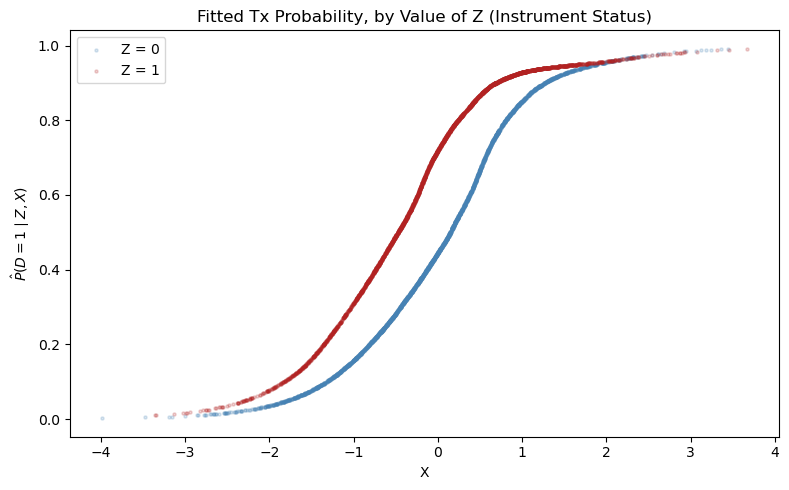

```python
X = X_train.detach().cpu().numpy().reshape(-1)
Z = Z_train.detach().cpu().numpy().reshape(-1)
D = fitted_values.detach().cpu().numpy().reshape(-1)

plot_data = pd.DataFrame({
    'X': X,
    'Z': Z,
    'D_hat': D
})
fig, ax = plt.subplots(figsize=(8, 5))

for z_val, color in [(0, 'steelblue'), (1, 'firebrick')]:
    subset = plot_data[plot_data['Z'] == z_val].sort_values('X')
    ax.scatter(subset['X'], subset['D_hat'],
               s=5, alpha=0.2, color=color, label=f'Z = {z_val}')


ax.set_xlabel('X')
ax.set_ylabel(r'$\hat{P}(D=1 \mid Z, X)$')
ax.set_title('Fitted Tx Probability, by Value of Z (Instrument Status)')
ax.legend()
plt.tight_layout()
plt.show()
```

It looks like our instrument status $Z = 1$ is positively correlated with treatment, which is what we want to see! So the NN seems to be working for this part at least.

### The Second Stage

Now to fit the second stage, $h()$. This takes as inputs $D$ and $X$ and outputs a single value, so this is going to look very similar to the first stage, except for the fact that its output won't be probabilities of our two treatment classes, but rather a single real-valued number, which we'll use to estimate $Y$:

```python
class OutcomeNN(nn.Module):
    def __init__(self, input_size, hidden_layers):
        super().__init__()
        layers = []
        in_dim = input_size
        for h in hidden_layers:
            layers += [nn.Linear(in_dim, h), nn.ReLU()]
            in_dim = h
        layers.append(nn.Linear(in_dim, 1))
        self.net = nn.Sequential(*layers)

    def forward(self, d, x):
        """Feed in D and X, return estimate"""
        inp = torch.cat([d, x], dim=-1)
        return self.net(inp)
```

Where it substantively differs from the first stage is the loss function used to fit it. With a classification problem like the Treatment Network, we used standard Cross Entropy Loss, which is built into the PyTorch library. Here, we'll need to manually build the loss outlined by Hartford et al.:

$$\mathcal{L}(T; \theta) = |T|^{-1} \sum_t(y_t - \int h_{\theta}(d, x_t) d\hat{F}_{\phi}(d | x_t, z_t))^2$$

Where $|T|$ denotes the size of our training set and $t$ indexes observations in the training set. Normally this sort of integral loss function would be tricky, but the authors suggest a useful workaround: we can get an unbiased estimate of the above loss function by replacing the integral in this equation with a $\textbf{sum}$ using samples from the fitted distribution we found in stage 1:

$$\mathcal{L}(T; \theta) \approx |T|^{-1} \sum_t (y_t - \frac{1}{B} \sum_{\dot{d} \sim \hat{F}_{\phi}(d | x_t, z_t)} h_{\theta}(\dot{d}, x_t))^2 := \hat{\mathcal{L}}(D; \theta)$$

Independent samples are going to have to be drawn for every integral calculation from the fitted distribution; this is why the TreatmentNN() class has a sample() method. So below, we'll put this together into a custom loss function. Note we are setting B=5 here for computational feasibility, but as discussed in subsequent sections, this may contribute to a noisy estimate and should be tuned appropriately. We'll use this loss function in a typical ML way; we'll fit the model in the training set using it, then seek to minimize the MSE these weights generate in a testing set. As the authors note, this is vital for causal validation. In the evaluation section, we'll test the model in a final holdout set, which we split out above.

```python
def second_stage_loss(stage1, stage2, Z, X, Y, n_samples=5):
    """
    stage 1: TreatmentNN Model
    stage 2: OutcomeNN Model
    n_samples: (B) as defined in loss function (default to 5 as described above)
    """
    stage1.eval() #we're done fitting stage 1, so use eval() to say we're evaluating

    n = Z.shape[0]

    #draw our independent samples from fitted distribution:
    with torch.no_grad(): #no gradient, because we're predicting not training (saves computation)
        D_samples = stage1.sample(Z, X, n_samples=n_samples)
        D_samples = D_samples.reshape(n, n_samples)

        assert D_samples.shape == (n, n_samples) #make sure the data is the correct shape

    #need to reshape our data to have a consistent shape to feed into the NN

    X_rep = X.unsqueeze(1).repeat(1, n_samples, 1)  #(n, B, 1)
    X_rep = X_rep.reshape(n * n_samples, X.shape[1])
    D_rep = D_samples.reshape(n * n_samples, 1).float()

    #compute estimate by averaging h() over the drawn samples (and reshaping correctly)
    h_rep = stage2(D_rep, X_rep)
    h_rep = h_rep.reshape(n, n_samples)

    h_mean = h_rep.mean(dim=1, keepdim=True)

    #calculate MSE loss
    loss = ((Y - h_mean) **2).mean()

    return loss
```

Now, we can fit the second stage. This will use a similar algorithm above, but subtituting the loss function we just made above in.

```python
def train_stage2(stage1, D_train, X_train, Y_train, D_test, X_test, Y_test, Z_train, Z_test):

    stage2 = OutcomeNN(
        input_size = D_train.shape[1] + X_train.shape[1],
        hidden_layers = [32, 32] #as before
    )

    #adam as before
    s2_optimizer = torch.optim.Adam(stage2.parameters(), lr=1e-3)

    best_loss, wait, patience = float('inf'), 0, 10

    for epoch in range(200):

        #same procedure as stage1 algorithm
        stage2.train()
        s2_optimizer.zero_grad()

        #explicitly pass stage1 function into loss function, as it needs to draw from it.
        #this is why "stage1" is a positional arg in the function, but stage2 isn't - we can
        #initialize the second NN in the training function, and output the trained model, but
        #stage1 needs to be passed in already trained. While this could be done in one function,
        #it's useful to see it done step by step to see the process

        loss = second_stage_loss(stage1, stage2, Z_train, X_train, Y_train, n_samples=5)
        loss.backward()
        s2_optimizer.step()

        #validation as before
        stage2.eval()
        with torch.no_grad():
            val_loss = second_stage_loss(stage1, stage2, Z_test, X_test, Y_test, n_samples=5)

        if val_loss.item() < best_loss:
            best_loss = val_loss
            best_weights = copy.deepcopy(stage2.state_dict())
            wait = 0

        #break early if converging - loss not getting lower.
        else:
            wait += 1
            if wait >= patience:
                break

    #load best model in as before
    stage2.load_state_dict(best_weights)

    #output trained model
    trained_model = stage2

    return trained_model

stage2 = train_stage2(stage1, D_train, X_train, Y_train, D_test, X_test, Y_test, Z_train, Z_test)
```

Great! So we have a first stage Neural Net that outputs treatment probabilities, a second Stage Outcome NN that we can use to estimate Y, and training functions for both. Now we can test how well it performs compared to the Wald with the different sample sizes from the data generating process above.

### Putting it Together

First, put everything above into one DeepIV function, that returns both stages given a sample size from our given data generating process. Note we must pass stage 1 function into the stage 2 function to generate draws:

```python
def DeepIV(Z_train, X_train, D_train, Y_train, Z_test, X_test, D_test, Y_test):

    stage1 = train_stage1(Z_train, X_train, D_train, Z_test, X_test, D_test)

    stage2 = train_stage2(stage1, D_train, X_train, Y_train, D_test, X_test, Y_test, Z_train, Z_test)

    return stage1, stage2
```

Now we need to evaluate its performance on a holdout set. Let's wrap everything into a single function that takes as arguments a number of samples and a seed (for reproducibility). This will then generate a set of data according to the DGP we defined in our generate_data() function, split it as before, and then fit two models: Deep IV, optimized as above, and the Wald estimand.

```python
def get_MSEs_and_ATEs(n_samples=1000, beta=3, pi=0.5, rho=0.7, seed=None):
    """
    A function that takes a number of samples as inputs, fits our two models (DeepIV and Wald), and outputs their respective MSEs and Beta estimates (called ATE for simplicity).
    """
    #generate shared data for each model (can change parameters in kwargs above)
    data = generate_data(n=n_samples, beta=beta, pi=pi, rho=rho, seed=seed)

    Z_train, X_train, D_train, Y_train, \
    Z_test, X_test, D_test, Y_test, \
    Z_ho, X_ho, D_ho, Y_ho = split_data(data)

    #### DEEP IV ####

    #fit our model
    stage1, stage2 = DeepIV(Z_train, X_train, D_train, Y_train, Z_test, X_test, D_test, Y_test)

    #set to eval
    stage1.eval()
    stage2.eval()

    #get fitted probabilities based on holdout set (distinct from training and test/validation set)
    with torch.no_grad():
        logits = stage1(Z_ho, X_ho)
        probs = torch.softmax(logits, dim=1)

        p0 = probs[:, 0:1]
        p1 = probs[:, 1:2]

    #counterfactual predictions based on these fitted values from stage1
    with torch.no_grad():
        f0 = stage2(torch.zeros_like(p0), X_ho)
        f1 = stage2(torch.ones_like(p1), X_ho)

    #use these to predict our outcome Y
    y_pred = p0 * f0 + p1 * f1

    #calculate MSE
    mse_deepIV = ((Y_ho - y_pred) ** 2).mean().item()

    #calculate ATE
    ate_deepIV = (f1 - f0).mean().item()

    #### WALD ESTIMAND ####
    df_ho = pd.DataFrame({
    'Y': Y_ho.squeeze().numpy(),
    'Z': Z_ho.squeeze().numpy(),
    'X': X_ho.squeeze().numpy(),
    'D': D_ho.squeeze().numpy()
})
    z1 = df_ho[df_ho['Z'] == 1]
    z0 = df_ho[df_ho['Z'] == 0]

    reduced_form = z1['Y'].mean() - z0['Y'].mean()
    first_stage  = z1['D'].mean() - z0['D'].mean()

    late_wald = reduced_form / first_stage

    return mse_deepIV, ate_deepIV, late_wald
```

### Evaluation

Almost done! Now to evaluate the two strategies with various sample sizes. I'm going to implement the same framework that the authors did: for each sample size, train each model 40 times and get the MSE. I will also get the estimand for each to assess bias. This will take a bit of time to run (about 15 minutes, typically), and longer if the training parameters above are increased.

```python
samples_to_test = [5000, 10000, 20000, 50000]

results = []

for sample in samples_to_test:

    for i in range(40):
        mse_deep_iv, ate_deep_iv, late_wald = get_MSEs_and_ATEs(n_samples=sample, seed=40600 + i)

        results.append({
            'Sample Size': sample,
            'Iteration': i,
            'Deep IV MSE': mse_deep_iv,
            'Deep IV Bias': ate_deep_iv - 3, #we set beta to 3 in our DGP by default, so we can compare to ground truth
            'Wald Estimand': late_wald,
            'Wald Bias': late_wald - 3 #comparison: how does Wald do, which is designed for this setting?
        })
```

Now let's plot the model results on one axis. Can DeepIV recover the ATE in this sort of setting?

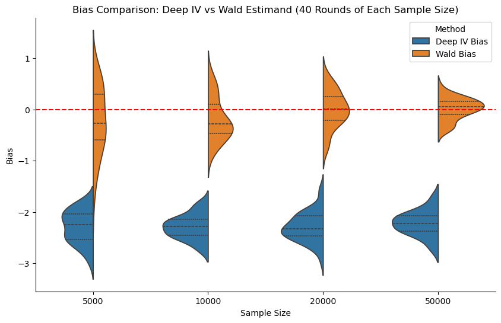

```python
simulation_results = pd.DataFrame(results)

df_melt_mse = simulation_results.melt(
    id_vars='Sample Size',
    value_vars=['Deep IV Bias', 'Wald Bias'],
    var_name='Method',
    value_name='Bias'
)

plt.figure(figsize=(10,6))

#plot distibution of biases for a given sample size
sns.violinplot(
    data=df_melt_mse,
    x='Sample Size',
    y='Bias',
    hue='Method',
    split=True,
    inner='quartile'
)

sns.despine()
plt.axhline(0, color='red', linestyle='--')

plt.title('Bias Comparison: Deep IV vs Wald Estimand (40 Rounds of Each Sample Size)')
plt.show()
```

Interesting! DeepIV gives much more precise estimates (the distribution of its Beta estimate is much tighter) at smaller samples, but it's really badly downward-biased. The Wald struggles at first (which isn't surprising given how strongly endogenous treatment is), but is generally unbiased at higher samples. This is relatively unsurprising, as we're specifying a DGP that the Wald is designed to handle: both a binary instrument and treatment. It's possible that by forcing nonlinearity (which DeepIV does by design) into a model that is structurally linear as we specified, the model overfits badly. We're specifying hundreds upon hundreds of parameters for a simple linear relationship! This is some evidence that you shouldn't just blindly choose DeepIV, as if you have strong evidence of a linear relationship you are far better off using 2SLS - both in terms of the actual performance of your model, and for computational cost.

How does the MSE of DeepIV fare?

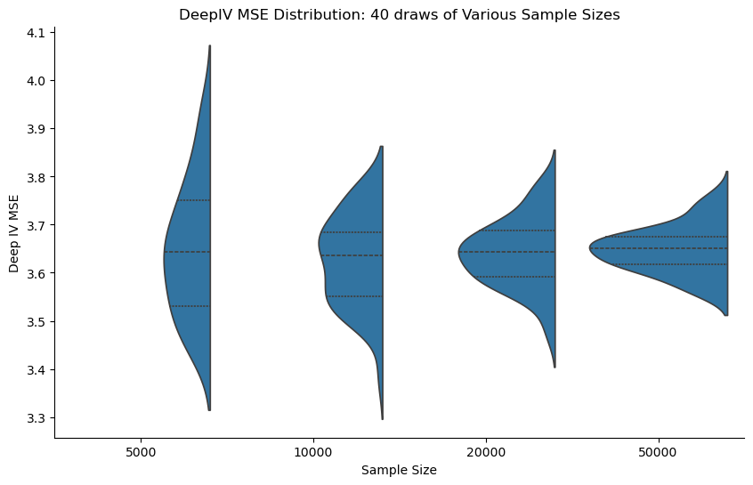

```python
plt.figure(figsize=(10,6))

#plot distibution of MSEs for a given sample size
sns.violinplot(
    data=simulation_results,
    x='Sample Size',
    y='Deep IV MSE',
    split=True,
    inner='quartile'
)

sns.despine()

plt.title('DeepIV MSE Distribution: 40 draws of Various Sample Sizes')
plt.show()
```

Looks pretty noisy - and while its MSE is generally getting tigher as the sample size increases, it seems like it would take a lot of data to make this workable. So it seems that in this "worst case" scenario, DeepIV isn't going to do much but return negatively biased, noisy estimands.

Of course, the process we've gone over isn't going to cover everything, as it's primarily meant to demonstrate the process of fitting such a model. For one, the authors specifically note that the variance of our estimate depnds on B, which is the number of samples we draw from the first stage fitted model. For computational feasibility, this tutorial sets this to only 5, but larger draws may be necessary to lower the variance of our DeepIV estimates, as well as hyperparameter tuning regarding the learning rate, number of layers, and number of nodes. It also remains to be seen if a continuous treatment, rather than a binary one, results in improved performance of DeepIV even in such a linear setting. However, this tutorial has hopefully served as an illuminating if simplified example of the general framework for implementing the DeepIV framework and comparing it to a well-established strategy (Wald Estimand) in a linear setting.

# Sources

Angrist, Joshua D., Guido W. Imbens, and Donald B. Rubin, "Identification of Casusal Effects Using Instrumental Variables". Journal of the American Statistical Association 91 No. 434 (1996) 444-455

Hartford, Jason, Greg Lewist, Kevin Leyton-Brown, and Matt Taddy, "Deep IV: A Flexible Approach for Counterfactual Prediction". $\textit{Proceedings of the 34th International Conference on Machine Learning}$, Sydney, Australia, PMLR 70, 2017

Hartford, Jason, "DeepIV", 2017, GitHub repository, https://github.com/jhartford/DeepIV

James, Gareth, Daniela Witten, Trevor Hastie, Robert Tibshirani, and Jonathan Taylor (2023). "10. Deep Learning" in $\textit{An Introduction to Statistical Learning with Applications in Python}$ (pp. 399-467). Springer Texts in Statistics, https://doi.org/10.1007/978-3-031-38747-0_10